# Manipulating Data from Nanoindenter

# Import packages

```python
import pandas as pd
import numpy as np
import matplotlib.pyplot as plt
import seaborn as sns
import subprocess
import os
import re as re
import matplotlib.cm as cm
%matplotlib notebook
```

# Load Data

The following function, 'read_NIfiles' loads the data that is obtained from Nanoindenter Burker Premier in the text format and create a pandas data frame holding all the features and the values. The text files are loaded from the current directory, so you need to move into the directory containing the files before running this function. This function converts the hardness measured by the nanoindenter in the unit of MPa into the one in the unit of 'Hv' byt the following relationship.

$H_{V} = 0.0924*H_{IT}$

Note: In the above relationship, $H_{IT}$ is in the unit of MPa. You need to multiple by 1,000 in order to convert it from GPa to MPa.

```python
def read_NIfiles(filename):
    with open(filename,'r') as file1:
        first_row = file1.readline()
        second_row = file1.readline()
        third_row = file1.readline()
        feature = third_row.split('\t')
        df = pd.DataFrame(columns=feature)
        row_num = int(first_row.split(' ')[5][0:3])

        for i in range(row_num):
            fourth_row = file1.readline().split('\t')
            df = df.append({feature[0]:fourth_row[0],
                    feature[1]:fourth_row[1],
                    feature[2]:fourth_row[2],
                    feature[3]:fourth_row[3],
                    feature[4]:fourth_row[4],
                    feature[5]:fourth_row[5],
                    feature[6]:fourth_row[6],
                    feature[7]:fourth_row[7],
                    feature[8]:fourth_row[8],
                    feature[9]:fourth_row[9],
                    feature[10]:fourth_row[10],
                    feature[11]:fourth_row[11],
                    feature[12]:fourth_row[12],
                    feature[13]:fourth_row[13],
                    feature[14]:fourth_row[14]
                   },ignore_index=True)
        df.iloc[:,1:13]=df.iloc[:,1:13].astype('float')
        df['HV']=df['H(GPa)']*0.0924*1000
    return df
```

Before running the function, the working directory is changed to the folder containing the data.

```python
wd=os.getcwd()
fileLoc=wd+'\\Overalldata'
os.chdir(fileLoc)
file_list = os.listdir()
```

```python
df1=read_NIfiles(file_list[0])
df2=read_NIfiles(file_list[1])
df3=read_NIfiles(file_list[2])
df4=read_NIfiles(file_list[3])
df5=read_NIfiles(file_list[4])
os.chdir('C:\\Users\\nobum\\Documents\\UBC_Research\\Research\\Nanoindenter')
```

## Quick look and Data manipulation

Before starting the data manipulation, let's take a look at the overall data. The following function check the data values if there are inifinite values, NaN or too high values. This gives you a sense of the data integrity.

```python
def check_Hardness(df):
    total = len(df['H(GPa)'])
    inf_num =sum(df['H(GPa)']==np.inf)
    na_num = sum(df['H(GPa)'].isna())
    file_name = df['File'][0]
    TooHigh_num = len(df['HV'][(df['H(GPa)']!=np.inf)&(df['H(GPa)'].notna())&(df['HV']>2000)])
    reasonable_num = total-(inf_num+na_num)-TooHigh_num
    print('The data for {}'.format(file_name))
    print('total length is {}'.format(total))
    print('The number of inf is {}'.format(inf_num))
    print('The number of na is {}'.format(na_num))
    print('The number of too high hardness values is {}'.format(TooHigh_num))
    print('\n')
    print('The number of reasonable values is {}'.format(reasonable_num))
    print('(*The criteria is 2000 HV)')
    print('--------------------------------------------------------------------')
    print('\n')
```

```python
check_Hardness(df1)
check_Hardness(df2)
check_Hardness(df3)
check_Hardness(df4)
check_Hardness(df5)
```

```
The data for 100uN_1um_20x20 LC.hys
total length is 400
The number of inf is 0
The number of na is 0
The number of too high hardness values is 0


The number of reasonable values is 400
(*The criteria is 2000 HV)
--------------------------------------------------------------------


The data for 100uN_3um_20x20 LC.hys
total length is 400
The number of inf is 46
The number of na is 62
The number of too high hardness values is 12


The number of reasonable values is 280
(*The criteria is 2000 HV)
--------------------------------------------------------------------


The data for 100uN_3um_20x20 LC.hys
total length is 400
The number of inf is 123
The number of na is 90
The number of too high hardness values is 2


The number of reasonable values is 185
(*The criteria is 2000 HV)
--------------------------------------------------------------------


The data for 100uN_1um_20x20 LC.hys
total length is 400
The number of inf is 0
The number of na is 30
The number of too high hardness values is 3


The number of reasonable values is 367
(*The criteria is 2000 HV)
--------------------------------------------------------------------


The data for 100uN_2um_20x20 LC.hys
total length is 400
The number of inf is 0
The number of na is 46
The number of too high hardness values is 8


The number of reasonable values is 346
(*The criteria is 2000 HV)
--------------------------------------------------------------------
```

Based on the above analysis, I build a function that is extracting rows containing the values that are not 'Inf', 'NaN' or less than 2000 HV because the expected hardness of the martensite ranges between 300 and 2000 Hv from the literature. This function can accept the argument of Hvmax. The default value is 2000.

```python
def reasonable_data(df,Hvmax=2000):
    df_reasonable =  df[(df['H(GPa)']!=np.inf)&(df['H(GPa)'].notna())&(df['HV']<Hvmax)]
    return df_reasonable
```

```python
df1_rnb=reasonable_data(df1)
df2_rnb=reasonable_data(df2)
df3_rnb=reasonable_data(df3)
df4_rnb=reasonable_data(df4)
df5_rnb=reasonable_data(df5)
```

# Hardness distribution

The following functions displays the histogram that represents the distribution of hardness. The function also caluclates the mean and the standard deviation and puts them close to the bars in the charts. This function requires the data and title. Binmax specifies the maximum value in the X-axis. The default is set as 600, which is a reasonable upper limit for this material. The second function is almost the same with the first one. The only differenct is that it gives the image file in the format of `.png`.

```python
def hardness_hist_600(df,title,binmax=600):

    mu = df['HV'].mean()
    sigma = df['HV'].std()

    textstr = '\n'.join((
        r'$\mu=%.2f$' % (mu, ),
        r'$\sigma=%.2f$' % (sigma, )))

    fig, ax = plt.subplots()
    bin_range = range(200,binmax,10)
    ax.hist(x=df['HV'],bins = bin_range,density=True)
    ax.axvline(x=mu,color='navy',linestyle='--')

    plt.xlabel(r'Hardness (HV))')
    plt.ylabel('Density')
    plt.title(title)
    # these are matplotlib.patch.Patch properties
    props = dict(boxstyle='round', edgecolor='navy',facecolor='white', alpha=0.5)
    # place a text box in upper left in axes coords
    ax.text(mu+50,0.04, textstr,  fontsize=12,
            verticalalignment='top', bbox=props)
    plt.show()
```

```python
def hardness_hist_png(df,savename,binmax=600):

    mu = df['HV'].mean()
    sigma = df['HV'].std()

    textstr = '\n'.join((
        r'$\mu=%.2f$' % (mu, ),
        r'$\sigma=%.2f$' % (sigma, )))

    fig, ax = plt.subplots()
    bin_range = range(200,binmax,10)
    ax.hist(x=df['HV'],bins = bin_range,density=True)
    ax.axvline(x=mu,color='navy',linestyle='--')

    plt.xlabel(r'Hardness (HV))')
    plt.ylabel('Density')
    # these are matplotlib.patch.Patch properties
    props = dict(boxstyle='round', edgecolor='navy',facecolor='white', alpha=0.5)
    # place a text box in upper left in axes coords
    ax.text(mu+50,0.04, textstr,  fontsize=12,
            verticalalignment='top', bbox=props)
    figurename = 'fig/'+savename +'.png'
    plt.savefig(figurename)
```

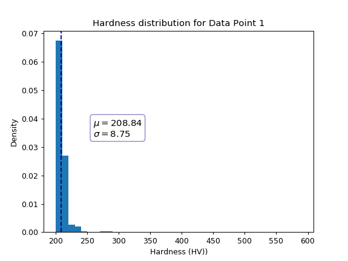

```python
hardness_hist_600(df1_rnb,'Hardness distribution for Data Point 1')
#hardness_hist_600(df1,title='Hardness distribution for Data Point 1',binmax=1000)
```

The histograms above show the hardness distribution of region #1. For region #1, most of the hardness values are close to the one of ferrite (200 Hv). This regions seems to be ferrite region.

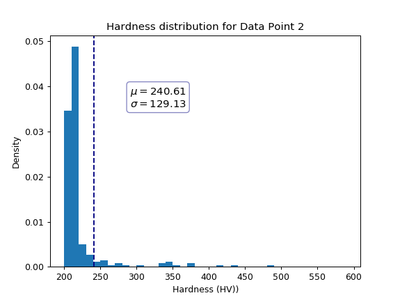

```python
hardness_hist_600(df2_rnb,'Hardness distribution for Data Point 2')
#hardness_hist_600(df2,title='Hardness distribution for Data Point 2',binmax=1000)
```

The above figure show the hardness distribution of region #2. For region #2, although a lot of data points are unrealistic, the majority of the hardness values are close to the one of ferrite. The variation of the hardness is much larger than #1.

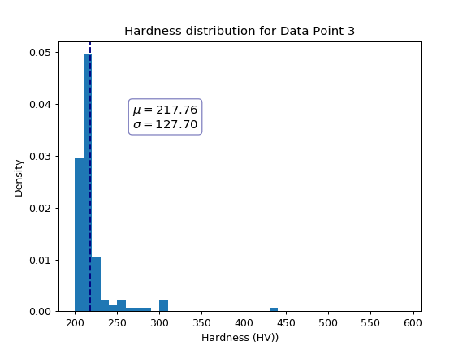

```python
hardness_hist_600(df3_rnb,'Hardness distribution for Data Point 3')
#hardness_hist_600(df3_rnb,'Hardness distribution for Data Point 3',binmax=2000)
```

The histograms above show the hardness distribution of region #3. For region #3, although a lot of data points are unrealistic, the majority of the hardness values are close to the one of ferrite. The variation of the hardness is much larger than #1.

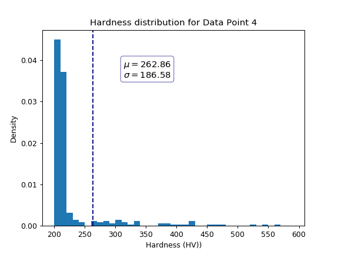

```python
hardness_hist_600(df4_rnb,'Hardness distribution for Data Point 4')
#hardness_hist_600(df4_rnb,'Hardness distribution for Data Point 4', binmax=2000)
```

For region #4, the majority of the hardness values are close to the one of ferrite (200 Hv).

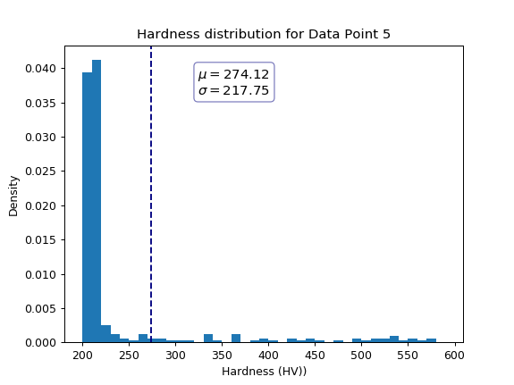

```python
hardness_hist_600(df5_rnb,'Hardness distribution for Data Point 5')
#hardness_hist_600(df5_rnb,'Hardness distribution for Data Point 5',binmax=2000)
```

For region #5, most of the hardness values are close to the one of ferrite (200 Hv).

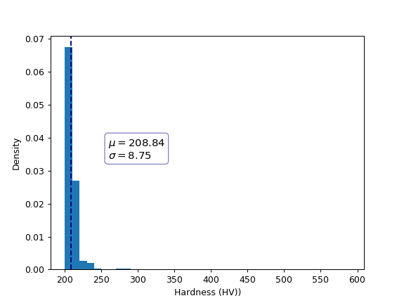

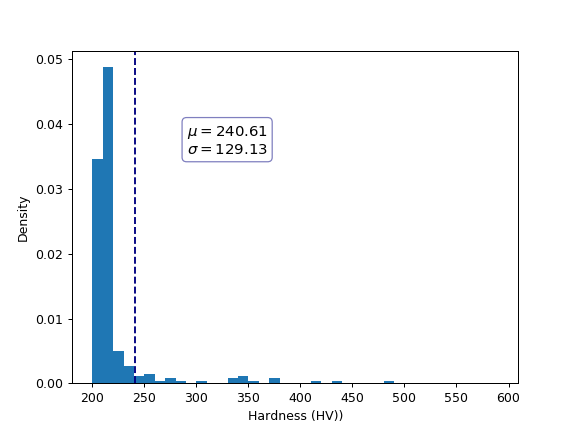

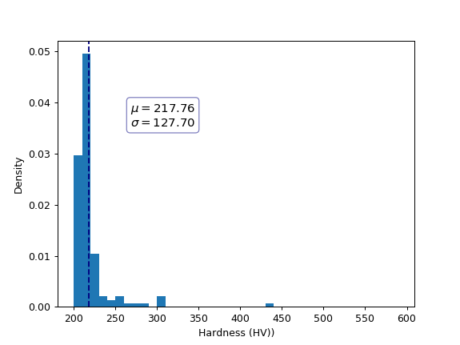

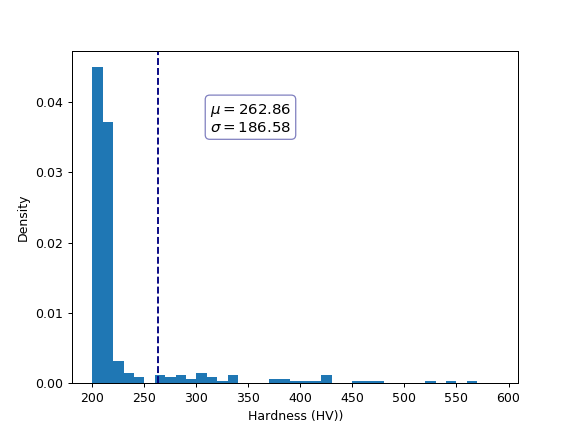

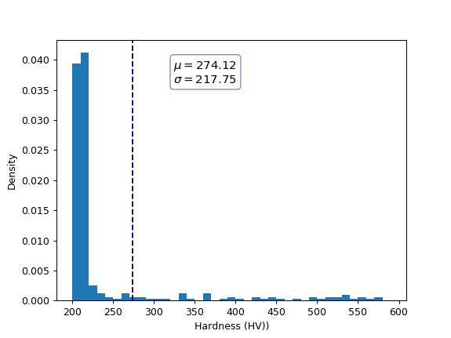

```python
hardness_hist_png(df1_rnb,'Dist_01_600')
hardness_hist_png(df2_rnb,'Dist_02_600')
hardness_hist_png(df3_rnb,'Dist_03_600')
hardness_hist_png(df4_rnb,'Dist_04_600')
hardness_hist_png(df5_rnb,'Dist_05_600')
```

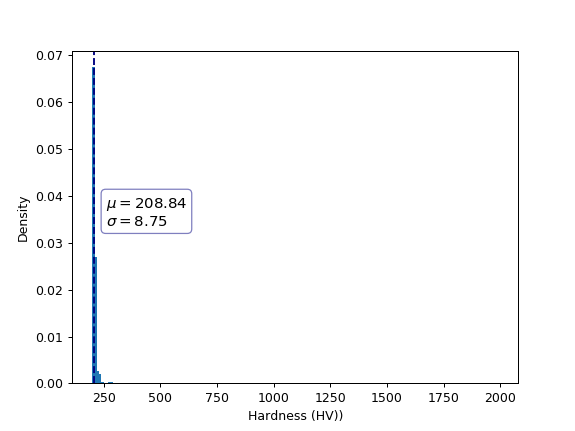

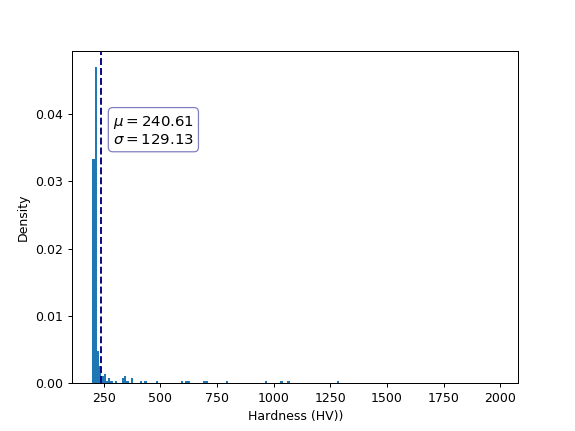

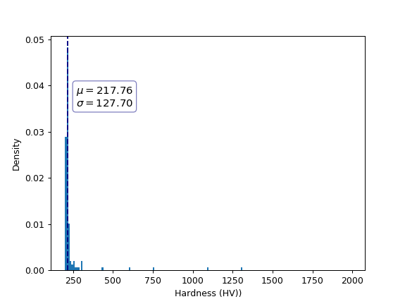

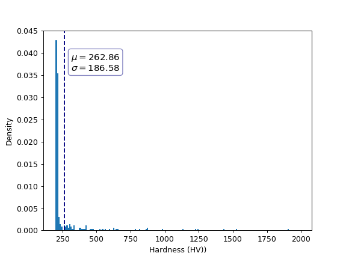

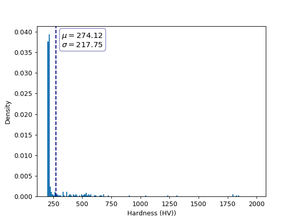

```python
hardness_hist_png(df1_rnb,'Dist_01_2000',binmax=2000)
hardness_hist_png(df2_rnb,'Dist_02_2000',binmax=2000)
hardness_hist_png(df3_rnb,'Dist_03_2000',binmax=2000)
hardness_hist_png(df4_rnb,'Dist_04_2000',binmax=2000)
hardness_hist_png(df5_rnb,'Dist_05_2000',binmax=2000)
```

# Hardness Map

As I mentioned earlier, the data files contain unrealistic values such as '+Inf' and 'NaN'. If we put these values with other reasonable values, we cannot see the map and distribution expected. To deal with this the issue, the following fucntion converts the unrealistic values into the fixed hardness value, here, 2000 as the default. After the modification, the hardness map will be created.

```python
def modify_data(df,Hvmax=2000):
    df_modi =  df
    for i in range(0,len(df)):
        if df_modi['H(GPa)'][i]==np.inf:
            df_modi['HV'][i]=Hvmax
        elif df_modi['HV'][i]>Hvmax:
            df_modi['HV'][i]=Hvmax
    df_modi=df_modi.fillna(Hvmax)
    return df_modi
```

```python
df1_modi = modify_data(df1)
df2_modi = modify_data(df2)
df3_modi = modify_data(df3)
df4_modi = modify_data(df4)
df5_modi = modify_data(df5)
```

The following functions display 2D heat map for hardness by using 'imshow' function. The first function gives a single map and the second gives two figures. The map is accompanied by the color bar. The third one gives in the format of `.png`. The function receives the arguments of `spacing`, which is the step size of the indentation, `vmax` and `vmin` which speficy the maximum and minimum of the color bar. The color variation of the left map is within reasonable hardness variation (200-600 Hv). On the other hand, the one of the right map is between 1000 and 2000. By black color in the right map, the distribution of unrealistic hardness values can be characterized.

```python
def heatmap(df_modi,spacing=20,vmax=600,vmin=200):
    X=df_modi['X(mm)'].unique()
    Y=df_modi['Y(mm)'].unique()

    Z=np.zeros([len(X),len(Y)])
    for j in range(0,len(X)):
        tempo=df_modi[df_modi['X(mm)']==X[j]]
        for i in range(0,len(Y)):
            Z[len(Y)-i-1,j]=tempo['HV'][tempo['Y(mm)']==Y[i]]
    Z=Z.astype('float')

    fig, ax = plt.subplots()
    #im = ax.imshow(Z, interpolation='nearest', cmap=cm.RdYlGn,
    im = ax.imshow(Z, interpolation='nearest', cmap=cm.Reds,
                   origin='lower', extent=[0, spacing, 0, spacing],
                   vmax=vmax, vmin=vmin)
    fig.colorbar(im,ax=ax)
    plt.xlabel(r'$X[\mu m]$')
    plt.ylabel(r'$Y[\mu m]$')
    plt.show()
```

```python
def heatmap2(df_modi,spacing=20,vmax1=600,vmin1=200):
    X=df_modi['X(mm)'].unique()
    Y=df_modi['Y(mm)'].unique()

    Z=np.zeros([len(X),len(Y)])
    for j in range(0,len(X)):
        tempo=df_modi[df_modi['X(mm)']==X[j]]
        for i in range(0,len(Y)):
            Z[len(Y)-i-1,j]=tempo['HV'][tempo['Y(mm)']==Y[i]]
    Z=Z.astype('float')

    fig, (ax1,ax2) = plt.subplots(1,2)
    #im = ax.imshow(Z, interpolation='nearest', cmap=cm.RdYlGn,
    im1 = ax1.imshow(Z, interpolation='nearest', cmap=cm.Reds,
                   origin='lower', extent=[0, spacing, 0, spacing],
                   vmax=vmax1, vmin=vmin1)
    cb1=plt.colorbar(im1,ax=ax1)
    ax1.set_xlabel(r'$X[\mu m]$')
    ax1.set_ylabel(r'$Y[\mu m]$')
    im2 = ax2.imshow(Z, interpolation='nearest', cmap=cm.Greys,
                   origin='lower', extent=[0, spacing, 0, spacing],
                   vmax=2000, vmin=1000)
    cb2=plt.colorbar(im2,ax=ax2)
    plt.xlabel(r'$X[\mu m]$')
    fig.tight_layout()
    plt.show()
```

```python
def heatmap_png(df_modi,savename,spacing=20,vmax1=600,vmin1=200):
    X=df_modi['X(mm)'].unique()
    Y=df_modi['Y(mm)'].unique()

    Z=np.zeros([len(X),len(Y)])
    for j in range(0,len(X)):
        tempo=df_modi[df_modi['X(mm)']==X[j]]
        for i in range(0,len(Y)):
            Z[len(Y)-i-1,j]=tempo['HV'][tempo['Y(mm)']==Y[i]]
    Z=Z.astype('float')

    fig, (ax1,ax2) = plt.subplots(1,2)
    #im = ax.imshow(Z, interpolation='nearest', cmap=cm.RdYlGn,
    im1 = ax1.imshow(Z, interpolation='nearest', cmap=cm.Reds,
                   origin='lower', extent=[0, spacing, 0, spacing],
                   vmax=vmax1, vmin=vmin1)
    cb1=plt.colorbar(im1,ax=ax1)
    ax1.set_xlabel(r'$X[\mu m]$')
    ax1.set_ylabel(r'$Y[\mu m]$')
    im2 = ax2.imshow(Z, interpolation='nearest', cmap=cm.Greys,
                   origin='lower', extent=[0, spacing, 0, spacing],
                   vmax=2000, vmin=1000)
    cb2=plt.colorbar(im2,ax=ax2)
    plt.xlabel(r'$X[\mu m]$')
    fig.tight_layout()
    figurename ='fig/'+ savename +'.png'
    plt.savefig(figurename)
```

```python
plt.clf
```

```
<function matplotlib.pyplot.clf()>
```

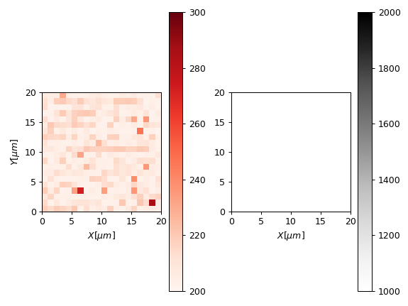

```python
heatmap2(df1_modi,vmax1=300,vmin1=200)
```

For #1, most of the region are close to the hardness of ferrite. This map also indicates that the region is ferrite region.

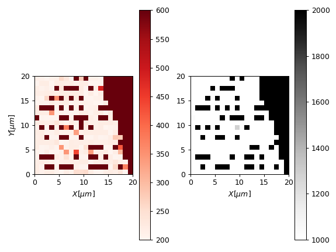

```python
heatmap2(df2_modi)
```

For #2, the right region of the measured area is covered by unrealistic values. This means that the measurement failed in the right region due to uneven surface or dust. The distribution of high values in the left and middle region indicates that high hardness values in this regions are attributed to dust or diamond particle which is about 1 μm. This will be able to be avoided by careful rinsing after polishing.

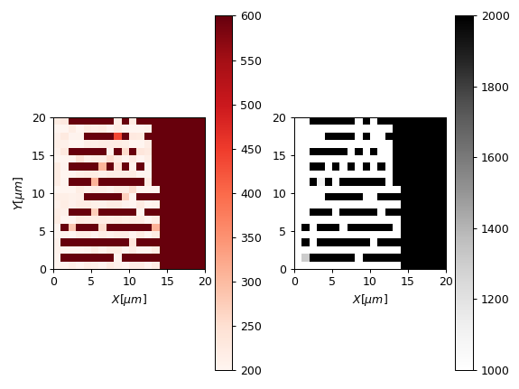

```python
heatmap2(df3_modi)
```

As is the case with #2, for #3, the right region of the measured area is covered by unrealistic values. This means that the measurement failed in the right region due to uneven surface or dust.

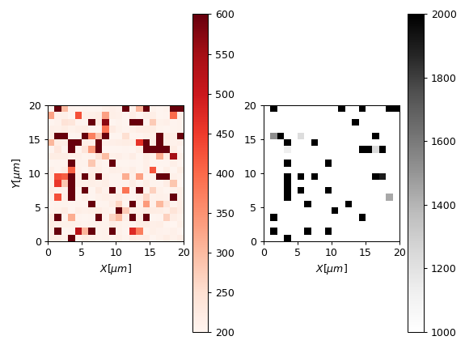

```python
heatmap2(df4_modi)
```

For #4, the unrealistic values are randomly distributed. This indicates that these are attributed to dust or diamond particle.

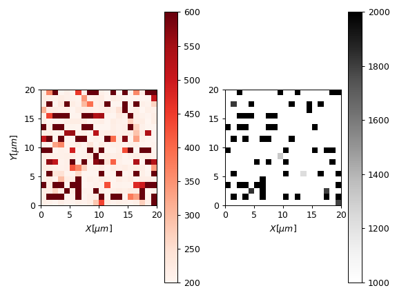

```python
heatmap2(df5_modi)
```

As is the case with #4, for #5, the unrealistic values are distributed randomly. This indicates that these are attributed to dust or diamond particle.

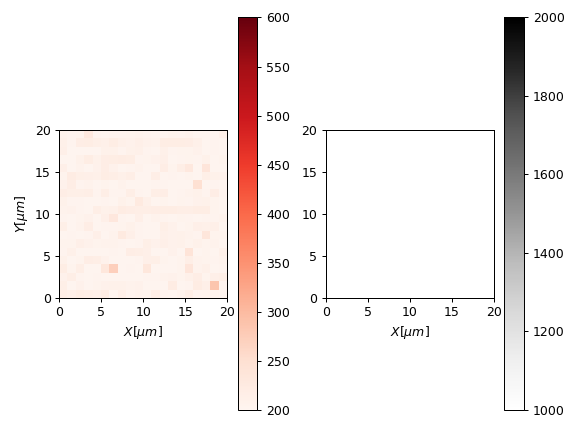

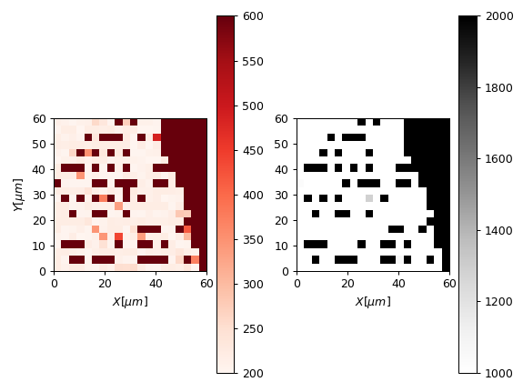

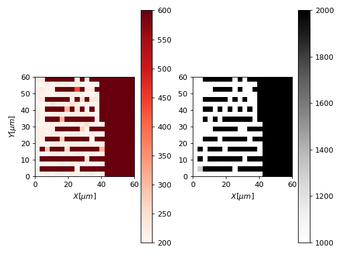

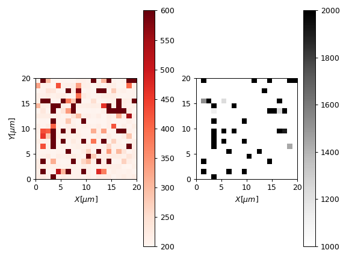

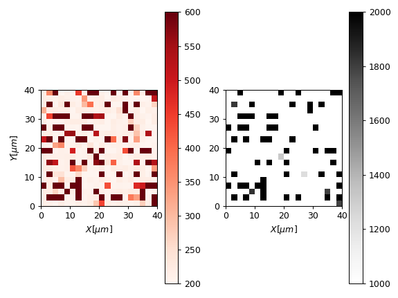

```python
heatmap_png(df1_modi,savename='Map_01_600')
heatmap_png(df2_modi,savename='Map_02_600',spacing=60)
heatmap_png(df3_modi,savename='Map_03_600',spacing=60)
heatmap_png(df4_modi,savename='Map_04_600')
heatmap_png(df5_modi,savename='Map_05_600',spacing=40)
```